# Heatmap for patterns of association in log-linear models

Below I provide code and step-by-step explanations to produce a heatmap for log odd-ratios from log-linear models. I exemplify the implementation in `R` using data on intergenerational class mobility for England, France and Sweden.

#### Steps:

1. Load the following packages for data manipulation (tidyverse,modelr,reshape2), log-linear model estimation (vcdExtra,logmult) and ploting (cowplot). Install previously if you do not have them.

```r
    library("tidyverse")
    library("modelr")
    library("reshape2")
    library("vcdExtra")
    library("logmult")
    library("cowplot")
```

2. Input the contingency table an turn it into a data frame. I use the dataset `erikson` from the package `gnm`, a dependency of package `logmult`. This is a cross-classification of subject’s occupational status (destination) and his father’s occupational status (origin) across 3 countries.

```r
    # Inpute data and create contingency table as data.frame()
    data(erikson)
    table <- ftable(erikson)
    mydata <- as.data.frame(table)
    levels(mydata$country) <- c("England-Wales","France","Sweden")

    # Save levels variables. To be used later.
    levels.origin      <- levels(mydata$origin)
    levels.destination <- levels(mydata$destination)
    levels.country     <- levels(mydata$country)
```

This is what the data looks like:

| origin | destination | country | Freq |
| --- | --- | --- | --- |
| I | I | England-Wales | 311 |
| II | I | England-Wales | 161 |
| III | I | England-Wales | 128 |
| IVa | I | England-Wales | 88 |
| IVb | I | England-Wales | 36 |
| IVc | I | England-Wales | 43 |
| V/VI | I | England-Wales | 356 |
| VIIa | I | England-Wales | 150 |
| VIIb | I | England-Wales | 12 |
| I | II | England-Wales | 130 |

[output cut: 233 more lines]

3. Next, I set the values to be used as reference categories.

```r
    # Set reference categories
    mydata$origin      <- relevel(mydata$origin, ref = "V/VI")
    mydata$destination <- relevel(mydata$destination, ref = "V/VI")
    mydata$country     <- relevel(mydata$country, ref = "England-Wales")
    mydata$Freq        <- mydata$Freq + 1 # add small constant to avoid problems with empty cells.
```

4. Fit different model specifications. Some of these modes are log-linear and other are log-multiplicative.

```r
# Fit models
# independence
indep <- gnm(Freq ~ (origin + destination)*country, family = poisson, data = mydata)
# quasi-perfect mobility
qpm  <- gnm(Freq ~ (origin + destination)*country + Diag(origin, destination)*country, family = poisson, data = mydata)
# row-column association 1
rc1 <- gnm(Freq ~ (origin + destination)*country + Mult(origin, destination) + Diag(origin, destination)*country, family = poisson, data = mydata)
```

```
Initialising
Running start-up iterations..
Running main iterations.........................................................................................................
Done
```

```r
# quasi-symmetry
qsymm <- gnm(Freq ~ (origin + destination)*country + Symm(origin, destination)*country, family = poisson, data = mydata)
# unidiff or log-multiplicative layers
unidiff <- gnm(Freq ~ (origin + destination)*country + Mult(Exp(country), origin:destination), family = poisson, data = mydata)
```

```
Initialising
Running start-up iterations..
Running main iterations........
Done
```

```r
# saturated
sat <- gnm(Freq ~ origin*destination*country, family = poisson, data = mydata)
# Compare models via godness of fit statistics
models <- glmlist(indep,qpm,rc1,qsymm,unidiff,sat)
LRstats(models)
```

```
Likelihood summary table:
           AIC    BIC LR Chisq  Df Pr(>Chisq)
indep   6498.4 6676.5   5152.6 192  < 2.2e-16 ***
qpm     3130.9 3403.4   1731.1 165  < 2.2e-16 ***
rc1     1973.4 2298.3    543.7 150  < 2.2e-16 ***
qsymm   1689.1 2244.5    127.3  84   0.001605 **
unidiff 1649.0 2057.7    171.2 126   0.004580 **
sat     1729.8 2578.6      0.0   0   1.000000
---
Signif. codes:  0 ‘***’ 0.001 ‘**’ 0.01 ‘*’ 0.05 ‘.’ 0.1 ‘ ’ 1
```

5. Goodness of fit statistics suggest that the `unidiff` models is the one that better fits the data. At this point I compute prediction from this model and from them, log odd ratios.

```r
# Create a synthetic dataset with all possible combinations of values
dummy.model <- lm(Freq ~ origin + destination + country, data=mydata)
new_x <- mydata %>% data_grid(origin,destination,country,.model=dummy.model)
# Compute predictions from different models. In this case: unidiff, quasi-symmetry and saturated model.
for ( m in c("unidiff","qsymm","sat")) {

  chosen_model <- eval(parse(text = m ))
  # Predicted counts
  predictions <- cbind(mydata%>% data_grid(origin,destination,country,.model=dummy.model), pred = predict(chosen_model, newdata=new_x)) %>%
    as_tibble()
  # Intercept
  intercept <- predictions %>% filter(origin=="V/VI", destination=="V/VI", country=="England-Wales") %>% dplyr::summarise(pred) %>% as.numeric()
  # Log odd ratios for marginal distributions
  predictions <- predictions %>% mutate(pred = pred - intercept) # remove intercept
  predictions_country     <- predictions %>% filter(origin=="V/VI", destination=="V/VI")  %>% rename(margin_country=pred) %>% select(country,margin_country)
  predictions_origin      <- predictions %>% filter(country=="England-Wales", destination=="V/VI") %>% rename(margin_origin=pred) %>% select(origin,margin_origin)
  predictions_destination <- predictions %>% filter(country=="England-Wales", origin=="V/VI") %>% rename(margin_destination=pred) %>% select(destination,margin_destination)
  # match
  predictions <- predictions %>% left_join(predictions_country, by="country")
  predictions <- predictions %>% left_join(predictions_origin, by="origin")
  predictions <- predictions %>% left_join(predictions_destination, by="destination")
  # Log odd ratios for marginal distributions origin and destination by country
  predictions_country_origin <- predictions %>% filter(origin!="V/VI",country!="England-Wales",destination=="V/VI") %>%
    rename(margin_country_origin=pred) %>% mutate(margin_country_origin = margin_country_origin - (margin_country + margin_origin )) %>%
    select(country,origin,margin_country_origin)
  predictions_country_destination <- predictions %>% filter(origin=="V/VI",country!="England-Wales",destination!="V/VI") %>%
    rename(margin_country_destination=pred) %>% mutate(margin_country_destination = margin_country_destination - (margin_country + margin_destination )) %>%
    select(country,destination,margin_country_destination)
  predictions <- predictions %>% left_join(predictions_country_origin, by=c("country","origin")) %>%  replace_na(list(margin_country_origin = 0))
  predictions <- predictions %>% left_join(predictions_country_destination, by=c("country","destination")) %>%  replace_na(list(margin_country_destination = 0))
  # Margin-free log-odd ratios (LORs)
  predictions <- predictions %>%
    mutate(`log-OR` = pred - (margin_country + margin_origin + margin_destination + margin_country_origin + margin_country_destination) )
  # Save predictions
  assign(paste0("predictions_",m),predictions)

}
```

6. Finally, for each model I visualize the estimated log odd ratios capturing margin-free association between origin and destination across countries . Of course, other quantities can also be visualized in the same way.

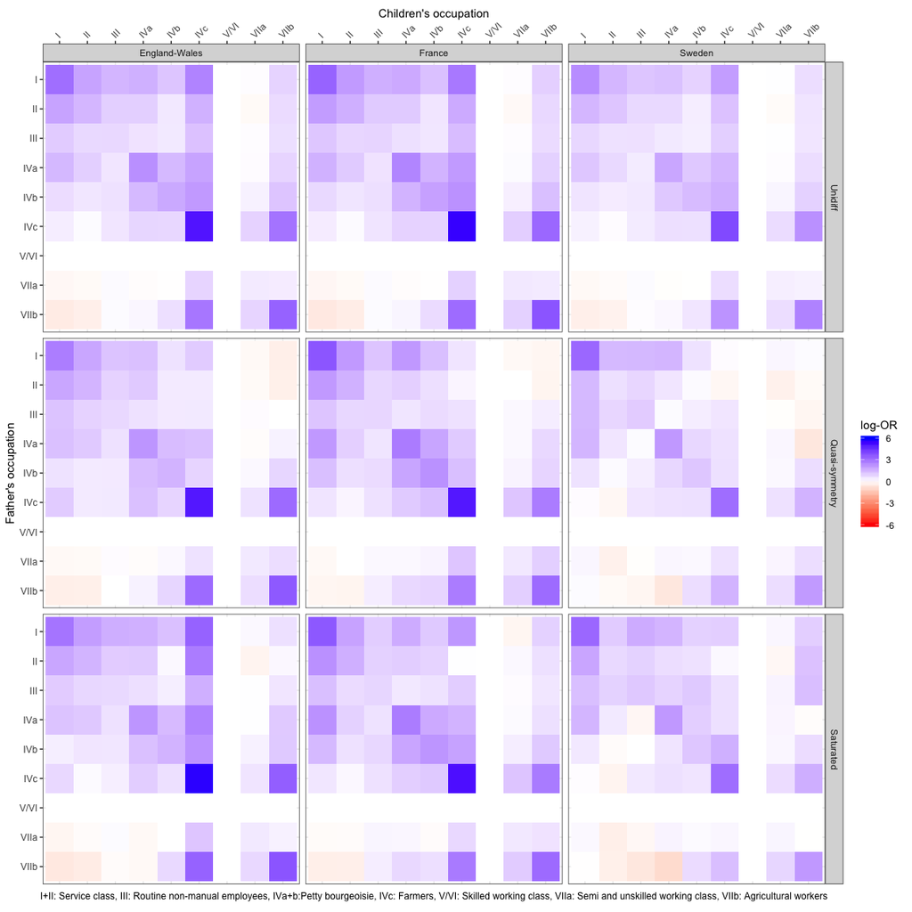

```r
# Combine models
predictions_unidiff <- predictions_unidiff %>% mutate(model = "Unidiff")
predictions_qsymm <- predictions_qsymm %>% mutate(model = "Quasi-symmetry")
predictions_sat <- predictions_sat %>% mutate(model = "Saturated")
predictions <- bind_rows(predictions_unidiff,predictions_qsymm,predictions_sat) %>%
  mutate(model = factor(model, levels=c("Unidiff","Quasi-symmetry","Saturated")))
# Plot
plot <- predictions %>%
  ggplot(aes(y=factor(origin, levels = rev(levels.origin)),
             x=factor(destination, levels = levels.destination))) + facet_grid(model ~ country) + geom_raster(aes(fill= `log-OR`)) +
  scale_fill_gradientn(limits=c(-6,6), colours=c("red","white","blue")) +
  labs(y="Father's occupation", x= "Children's occupation", colour="") +
  theme_bw() + theme(axis.text.x = element_text(size=9, angle=45, vjust=-1, hjust=0),
                     axis.text.y = element_text(size=9, angle=0),
                     plot.title= element_text(size=11)) +
  scale_x_discrete(position="top")
# Add labels
plot <- plot %>% add_sub(.,"I+II: Service class, III: Routine non-manual employees, IVa+b:Petty bourgeoisie, IVc: Farmers, V/VI: Skilled working class, VIIa: Semi and unskilled working class, VIIb: Agricultural workers", size= 9) %>%  ggdraw()
print(plot)
```